# W207 Final Project: Lending Club Loan Data Default Classification

Michael Zeng, Param Viswanathan

# Introduction

# Loading Data and Visualization

## Download the Data

```python
import kaggle

kaggle.api.authenticate()

kaggle.api.dataset_download_files('wendykan/lending-club-loan-data',
                                  path='/Users/zengm71/Documents/Berkeley/\
                                        W207/ucb-w207-applied-ml/projects/\
                                        lending_club/',
                                  unzip=True)
```

```python
df = pd.read_csv("loan.csv", low_memory=False)
df.head()
```

|  | id | member_id | loan_amnt | funded_amnt | funded_amnt_inv | term | int_rate | installment | grade | sub_grade | ... | hardship_payoff_balance_amount | hardship_last_payment_amount | disbursement_method | debt_settlement_flag | debt_settlement_flag_date | settlement_status | settlement_date | settlement_amount | settlement_percentage | settlement_term |
| --- | --- | --- | --- | --- | --- | --- | --- | --- | --- | --- | --- | --- | --- | --- | --- | --- | --- | --- | --- | --- | --- |
| 0 | NaN | NaN | 2500 | 2500 | 2500.0 | 36 months | 13.56 | 84.92 | C | C1 | ... | NaN | NaN | Cash | N | NaN | NaN | NaN | NaN | NaN | NaN |
| 1 | NaN | NaN | 30000 | 30000 | 30000.0 | 60 months | 18.94 | 777.23 | D | D2 | ... | NaN | NaN | Cash | N | NaN | NaN | NaN | NaN | NaN | NaN |
| 2 | NaN | NaN | 5000 | 5000 | 5000.0 | 36 months | 17.97 | 180.69 | D | D1 | ... | NaN | NaN | Cash | N | NaN | NaN | NaN | NaN | NaN | NaN |
| 3 | NaN | NaN | 4000 | 4000 | 4000.0 | 36 months | 18.94 | 146.51 | D | D2 | ... | NaN | NaN | Cash | N | NaN | NaN | NaN | NaN | NaN | NaN |
| 4 | NaN | NaN | 30000 | 30000 | 30000.0 | 60 months | 16.14 | 731.78 | C | C4 | ... | NaN | NaN | Cash | N | NaN | NaN | NaN | NaN | NaN | NaN |

5 rows × 145 columns

## Visualization

In this section, we try to visualized the data to get an idea of the features available.

- Loan Amount

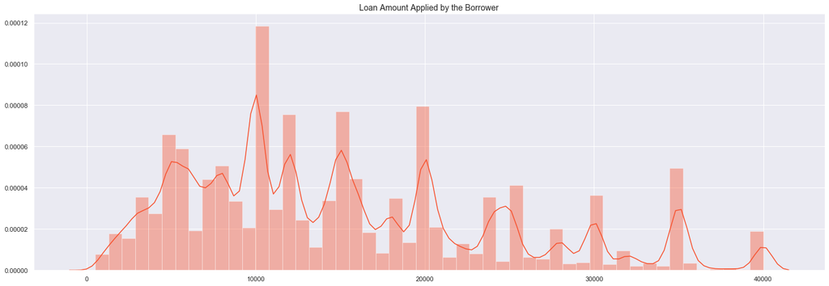

```python
fig, ax = plt.subplots(1, figsize=(24,8))
df['year'] = pd.to_datetime(df['issue_d']).dt.year
loan_amount = df["loan_amnt"].values
sns.distplot(loan_amount, color="#F7522F")
ax.set_title("Loan Amount Applied by the Borrower", fontsize=14)
```

- Rating Grade

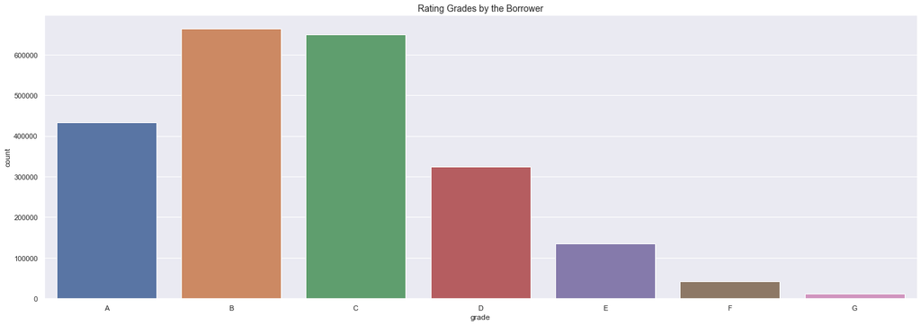

```python
fig, ax = plt.subplots(1, figsize=(24,8))
sns.countplot(x = 'grade', data=df,
              order= ['A', 'B', 'C', 'D', 'E', 'F', 'G'])
ax.set_title("Rating Grades by the Borrower", fontsize=14)
```

- Fine Rating Grade

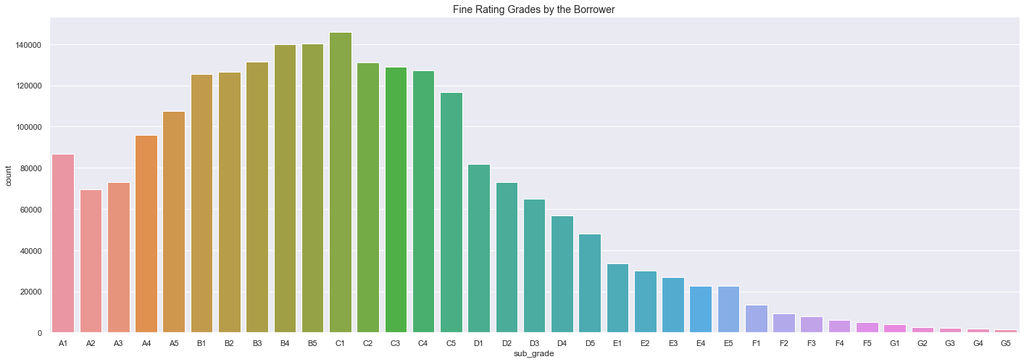

```python
fig, ax = plt.subplots(1, figsize=(24,8))
sns.countplot(x = 'sub_grade', data=df,
              order=np.sort(df.sub_grade.unique()))
ax.set_title("Fine Rating Grades by the Borrower", fontsize=14)
```

- Interest Rate

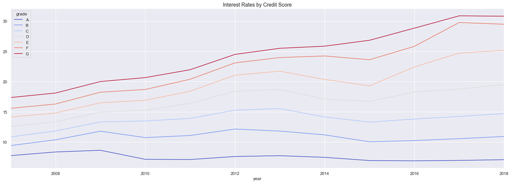

```python
f, ax = plt.subplots(1, figsize=(24,8))
cmap = plt.cm.coolwarm

by_inc = df.groupby(['year', 'grade']).int_rate.mean()
by_inc.unstack().plot(ax=ax, colormap=cmap)
ax.set_title('Interest Rates by Credit Score', fontsize=14)
```

- Employment Length

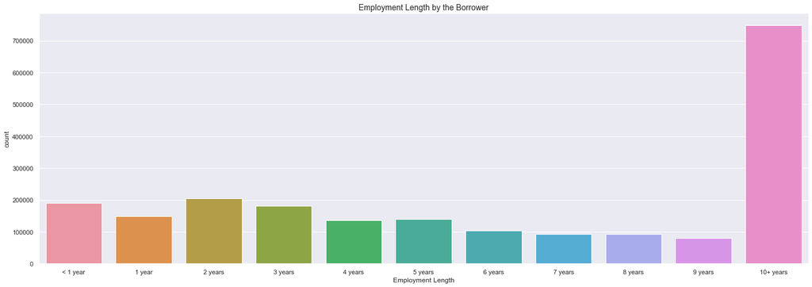

```python
fig, ax = plt.subplots(1, figsize=(24,8))
sns.countplot(x = 'emp_length', data=df,
              order = ['< 1 year', '1 year', '2 years', '3 years','4 years', '5 years', '6 years', '7 years',
                      '8 years', '9 years', '10+ years'])
ax.set_title("Employment Length by the Borrower", fontsize=14)
plt.xlabel('Employment Length')
```

- Bad Loans

  There are 9 loan status labeled in the data:

```python
df["loan_status"].value_counts()
```

```
Fully Paid                                             1041952
Current                                                 919695
Charged Off                                             261655
Late (31-120 days)                                       21897
In Grace Period                                           8952
Late (16-30 days)                                         3737
Does not meet the credit policy. Status:Fully Paid        1988
Does not meet the credit policy. Status:Charged Off        761
Default                                                     31
Name: loan_status, dtype: int64
```

For this project, we deem any loans NOT labeled either `Current` or `Fully Paid` as bad loans.

*Note that some of the loans are still within terms, and can potentially still default in the future. This is dealt with in the latter data cleaning section.*

```
[Text(0, 0.5, '(%)')]
```

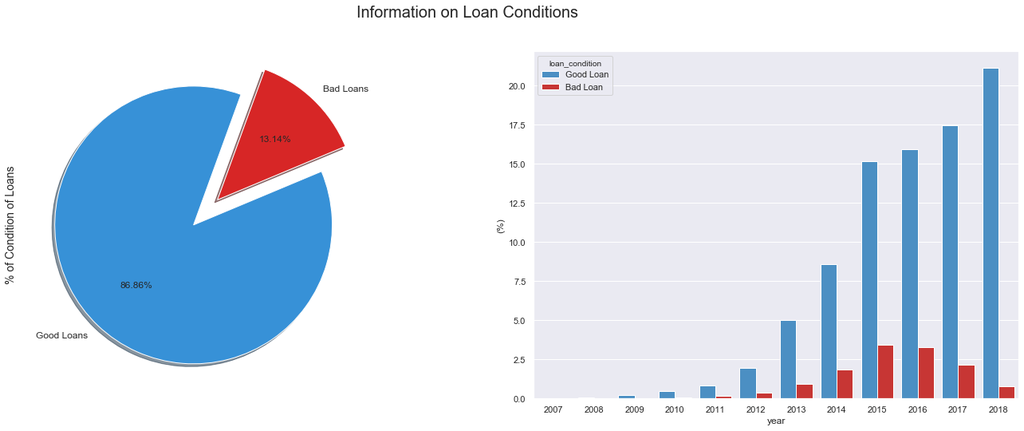

```python
f, ax = plt.subplots(1,2, figsize=(24,8))
colors = ["#3791D7", "#D72626"]
labels ="Good Loans", "Bad Loans"
plt.suptitle('Information on Loan Conditions', fontsize=20)
df["loan_condition"].value_counts().plot.pie(explode=[0,0.25],
                                             autopct='%1.2f%%', ax=ax[0], shadow=True, colors=colors,
                                             labels=labels, fontsize=12, startangle=70)
ax[0].set_ylabel('% of Condition of Loans', fontsize=14)
palette = ["#3791D7", "#E01E1B"]
sns.barplot(x="year", y="loan_amnt", hue="loan_condition",
            data=df, palette=palette,
            estimator=lambda x: len(x) / len(df) * 100)
ax[1].set(ylabel="(%)")
```

- With bad loans labeled, let's revisit the rating grade and interest rate, which are likely the two factors for default.

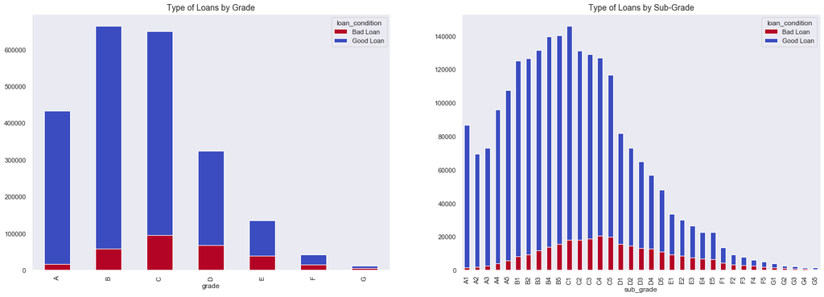

```python
f, ax = plt.subplots(1,2, figsize=(24,8))
cmap = plt.cm.coolwarm_r
loans_by_region = df.groupby(['grade', 'loan_condition']).size()
loans_by_region.unstack().plot(kind='bar', stacked=True, colormap=cmap, ax=ax[0], grid=False)
ax[0].set_title('Type of Loans by Grade', fontsize=14)
loans_by_grade = df.groupby(['sub_grade', 'loan_condition']).size()
loans_by_grade.unstack().plot(kind='bar', stacked=True, colormap=cmap, ax=ax[1], grid=False)
ax[1].set_title('Type of Loans by Sub-Grade', fontsize=14)
```

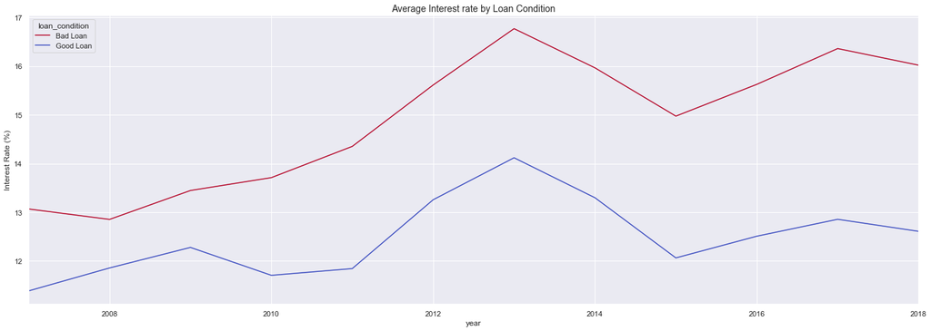

```python
fig, ax = plt.subplots(1, figsize=(24,8))
by_interest = df.groupby(['year', 'loan_condition']).int_rate.mean()
by_interest.unstack().plot(ax=ax, colormap=cmap)
ax.set_title('Average Interest rate by Loan Condition', fontsize=14)
ax.set_ylabel('Interest Rate (%)', fontsize=12)
```

# Data Cleaning

The data is updated 4 months ago. For loans issued recently that are still in term (not yet defaulted), we are not sure if they are going to default. So the first thing to do is to remove them so that we are left with a data set with reliable labels.

```python
# the data set is as of 4 months ago
df['loan_age_months'] = df.issue_d.apply(lambda x: (datetime.now() - datetime.strptime(x, '%b-%Y')).days / 30) - 4
df['term_months'] = (df.term == ' 36 months') * 36 + (1 - (df.term == ' 36 months')) * 60
sum(df.term_months > df.loan_age_months) / df.shape[0]
```

```
0.6347017784123985
```

This shows that about 63% of the loans are still within their terms. For these loans, unless they have already defaulted, we can't really trust the labels. We will remove the loans that might still default from our modeling dataset `df_m`.

```python
bad_loan_status = ["Charged Off", "Default", "Does not meet the credit policy. Status:Charged Off",
                   "In Grace Period", "Late (16-30 days)", "Late (31-120 days)"]
might_still_default = (df.loan_status == 'Current') & (df.term_months > df.loan_age_months)

# data frame for modeling
df_m = df[~ might_still_default]
df_m.shape[0] / df.shape[0]
```

```
0.605752812885395
```

We are now left with about 60% of the original observations, for which we know the labels are trustworthy.

## Take out columns that are mostly NAs

We plan to leave all the numerical features in, while one-hot encode all the categorical ones.

```python
df_m.dtypes
```

```
id                                            float64
member_id                                     float64
loan_amnt                                       int64
funded_amnt                                     int64
funded_amnt_inv                               float64
term                                           object
int_rate                                      float64
installment                                   float64
grade                                          object
sub_grade                                      object
emp_title                                      object
emp_length                                     object
home_ownership                                 object
annual_inc                                    float64
verification_status                            object
issue_d                                        object
loan_status                                    object
pymnt_plan                                     object
url                                           float64
desc                                           object
purpose                                        object
title                                          object
zip_code                                       object
addr_state                                     object
dti                                           float64
delinq_2yrs                                   float64
earliest_cr_line                               object
inq_last_6mths                                float64
mths_since_last_delinq                        float64
mths_since_last_record                        float64
                                               ...
sec_app_chargeoff_within_12_mths              float64
sec_app_collections_12_mths_ex_med            float64
sec_app_mths_since_last_major_derog           float64
hardship_flag                                  object
hardship_type                                  object
hardship_reason                                object
hardship_status                                object
deferral_term                                 float64
hardship_amount                               float64
hardship_start_date                            object
hardship_end_date                              object
payment_plan_start_date                        object
hardship_length                               float64
hardship_dpd                                  float64
hardship_loan_status                           object
orig_projected_additional_accrued_interest    float64
hardship_payoff_balance_amount                float64
hardship_last_payment_amount                  float64
disbursement_method                            object
debt_settlement_flag                           object
debt_settlement_flag_date                      object
settlement_status                              object
settlement_date                                object
settlement_amount                             float64
settlement_percentage                         float64
settlement_term                               float64
year                                            int64
loan_condition                                 object
loan_age_months                               float64
term_months                                     int64
Length: 149, dtype: object
```

Let's take a look at the percentage of NAs in each column:

```python
na_pct = df_m.isna().sum() / df_m.shape[0]
# we will simply remove the columns that are NA for more than 50% of the observations
df_m = df_m[na_pct[na_pct < 0.5].index]
df_m.shape
```

```
(1369406, 91)
```

We don't think we have enough information to make educated guesses for imputing those NAs. Besides, simple imputing might have inverse impact on the model predictions. Given this, we decided to simply drop these columns.

```python
na_pct = df_m.isna().sum() / df_m.shape[0]
na_pct.sort_values(ascending = False)
```

```
mths_since_recent_inq         0.130749
num_tl_120dpd_2m              0.089025
mo_sin_old_il_acct            0.079822
emp_title                     0.064516
emp_length                    0.059017
pct_tl_nvr_dlq                0.051431
avg_cur_bal                   0.051335
mo_sin_old_rev_tl_op          0.051319
mo_sin_rcnt_rev_tl_op         0.051319
num_rev_accts                 0.051319
num_rev_tl_bal_gt_0           0.051319
total_rev_hi_lim              0.051319
num_accts_ever_120_pd         0.051319
num_actv_bc_tl                0.051319
tot_cur_bal                   0.051319
num_actv_rev_tl               0.051319
num_il_tl                     0.051319
num_op_rev_tl                 0.051319
tot_coll_amt                  0.051319
mo_sin_rcnt_tl                0.051319
num_bc_tl                     0.051319
num_tl_30dpd                  0.051319
num_tl_90g_dpd_24m            0.051319
num_tl_op_past_12m            0.051319
total_il_high_credit_limit    0.051319
tot_hi_cred_lim               0.051319
bc_util                       0.047427
percent_bc_gt_75              0.047159
bc_open_to_buy                0.046857
mths_since_recent_bc          0.046173
                                ...
addr_state                    0.000000
home_ownership                0.000000
installment                   0.000000
int_rate                      0.000000
term                          0.000000
funded_amnt_inv               0.000000
funded_amnt                   0.000000
sub_grade                     0.000000
term_months                   0.000000
revol_bal                     0.000000
last_pymnt_amnt               0.000000
loan_condition                0.000000
year                          0.000000
debt_settlement_flag          0.000000
disbursement_method           0.000000
hardship_flag                 0.000000
loan_age_months               0.000000
application_type              0.000000
policy_code                   0.000000
collection_recovery_fee       0.000000
initial_list_status           0.000000
recoveries                    0.000000
total_rec_late_fee            0.000000
total_rec_int                 0.000000
total_rec_prncp               0.000000
total_pymnt_inv               0.000000
total_pymnt                   0.000000
out_prncp_inv                 0.000000
out_prncp                     0.000000
loan_amnt                     0.000000
Length: 91, dtype: float64
```

## Deal with categorical variables

- Term

  The length of loan terms, either 36 months or 60 months.

```python
# term
# create 1 variable for 36 months
print(df_m.term.value_counts())
df_m['term_cat'] = (df_m.term == ' 36 months') * 1
df_m.term_cat.value_counts()
```

```
 36 months    1036761
 60 months     332645
Name: term, dtype: int64
```

```
1    1036761
0     332645
Name: term_cat, dtype: int64
```

- Grade

  The credit rating of the borrowers. Even though fine ratings are provided, we believe the coarse rating of A to G will give us sufficient granularity for the analysis.

```python
# grade
# create 1 variable for each grade, and drop G to avoid perfect colinearity
print(df_m.grade.value_counts())

for grade_i in df_m.grade.unique():
    df_m['grade_' + grade_i + '_cat'] = (df_m.grade == grade_i) * 1
df_m.drop(columns= 'grade_G_cat', inplace=True)
```

```
B    396666
C    389871
A    236464
D    206992
E     96684
F     33113
G      9616
Name: grade, dtype: int64
```

- Home Ownership

  We will encode only `mortage`, `rent` and `own`, leaving `any`, `other` and `NONE` as the alternative.

```python
# home_ownership
# create a variable for mortgage, rent and own each.
# "ANY", "OTHER" and "NONE" will be be represented as the alternative
print(df_m.home_ownership.value_counts())

for home_ownership in ['MORTGAGE', 'RENT', 'OWN']:
    df_m['home_ownership_' + home_ownership + '_cat'] = (df_m.home_ownership == home_ownership) * 1
```

```
MORTGAGE    675501
RENT        545438
OWN         147942
ANY            290
OTHER          182
NONE            53
Name: home_ownership, dtype: int64
```

- Verification Status

  Whether/how the information of borrowers are verified. Here we leave `Not Verified` as the alternative.

```python
# verification_status
# create a variable for 'Source Verified', 'Verified' each
print(df_m.verification_status.value_counts())

for verification_status_i in ['Source Verified', 'Verified']:
    df_m['verification_status_' + verification_status_i.replace(" ", "") + '_cat'] = \
    (df_m.verification_status == verification_status_i) * 1
```

```
Source Verified    531227
Verified           426392
Not Verified       411787
Name: verification_status, dtype: int64
```

- Employment Length

```python
# emp_length
print(df_m.emp_length.value_counts())

# transform emp_length into numerical
def extract_emp_length(x):
    if str(x).split()[0] == 'nan':
        return(0)
    elif str(x).split()[0] == '<':
        return(1)
    elif str(x).split()[0] == '10+':
        return(10)
    else:
        return(int(str(x).split()[0]))
df_m['emp_length_num'] = df_m['emp_length'].apply(lambda x: extract_emp_length(x))
```

```
10+ years    449807
2 years      123689
< 1 year     110185
3 years      109529
1 year        90137
5 years       85602
4 years       81942
6 years       63843
8 years       61719
7 years       60409
9 years       51726
Name: emp_length, dtype: int64
```

- Purpose

  Purpose of the loan application, leaving `educational` as the alternative.

```python
# purpose
print(df_m.purpose.value_counts())

# create one column for each purpose, and drop education
for purpose_i in df_m.purpose.unique():
    df_m['purpose_' + purpose_i + '_cat'] = (df_m.purpose == purpose_i) * 1

df_m.drop(columns= 'purpose_educational_cat', inplace=True)
```

```
debt_consolidation    793957
credit_card           299870
home_improvement       89019
other                  79823
major_purchase         29991
small_business         16033
medical                15901
car                    14802
moving                  9687
vacation                9198
house                   7401
wedding                 2350
renewable_energy         951
educational              423
Name: purpose, dtype: int64
```

- Hardship

```python
# hardship
print(df_m.hardship_flag.value_counts())

# create a column for hardship
df_m['hardship_flag_cat'] = (df_m.hardship_flag == 'Y') * 1
df_m.hardship_flag_cat.value_counts()
```

```
N    1368531
Y        875
Name: hardship_flag, dtype: int64
```

```
0    1368531
1        875
Name: hardship_flag_cat, dtype: int64
```

## Drop columns that might imply defaults

Settlement and recovery information only comes after a loan has defaulted. Therefore leaving those in will leak information about our labels, we need to leave them out for the modeling.

- Debt Settlement

```python
# debt_settlement_flag
# drop settle_ment_flag, since one only settles when already in default.
# for the same reason drop all the other columns about settlement

for i in df_m.columns:
    if 'settlement' in i:
        df_m.drop(columns= i, inplace=True)
        print('dropped column ' + i)
```

```
dropped column debt_settlement_flag
```

- Recovery Flag

```python
# rec_flag
# drop recovery related columns, because it happens after default
recoveries_col = ['total_rec_prncp', 'total_rec_int',
                  'total_rec_late_fee', 'recoveries',
                  'collection_recovery_fee']
for i in recoveries_col:
    df_m.drop(columns= i, inplace=True)
    print('dropped column ' + i)
```

```
dropped column total_rec_prncp
dropped column total_rec_int
dropped column total_rec_late_fee
dropped column recoveries
dropped column collection_recovery_fee
```

## Now that we have encoded the categorical variables we want, we can select the numerical columns and use that for modeling

```python
numeric_cols = list(df_m.dtypes[df_m.dtypes == 'int64'].index) + \
                list(df_m.dtypes[df_m.dtypes == 'float64'].index)
df_m_n = df_m[numeric_cols]
df_m_n.describe()
```

|  | loan_amnt | funded_amnt | revol_bal | policy_code | term_months | term_cat | grade_D_cat | grade_C_cat | grade_A_cat | grade_B_cat | ... | num_tl_op_past_12m | pct_tl_nvr_dlq | percent_bc_gt_75 | pub_rec_bankruptcies | tax_liens | tot_hi_cred_lim | total_bal_ex_mort | total_bc_limit | total_il_high_credit_limit | loan_age_months |
| --- | --- | --- | --- | --- | --- | --- | --- | --- | --- | --- | --- | --- | --- | --- | --- | --- | --- | --- | --- | --- | --- |
| count | 1.369406e+06 | 1.369406e+06 | 1.369406e+06 | 1369406.0 | 1.369406e+06 | 1.369406e+06 | 1.369406e+06 | 1.369406e+06 | 1.369406e+06 | 1.369406e+06 | ... | 1.299130e+06 | 1.298976e+06 | 1.304826e+06 | 1.368041e+06 | 1.369301e+06 | 1.299130e+06 | 1.319376e+06 | 1.319376e+06 | 1.299130e+06 | 1.369406e+06 |
| mean | 1.446531e+04 | 1.445664e+04 | 1.628472e+04 | 1.0 | 4.182989e+01 | 7.570881e-01 | 1.511546e-01 | 2.847008e-01 | 1.726763e-01 | 2.896628e-01 | ... | 2.179124e+00 | 9.412474e+01 | 4.529152e+01 | 1.341736e-01 | 5.274954e-02 | 1.739687e+05 | 4.970461e+04 | 2.157050e+04 | 4.216039e+04 | 4.675897e+01 |
| std | 8.736521e+03 | 8.732758e+03 | 2.247955e+04 | 0.0 | 1.029222e+01 | 4.288424e-01 | 3.581996e-01 | 4.512720e-01 | 3.779674e-01 | 4.536060e-01 | ... | 1.846343e+00 | 8.786840e+00 | 3.601876e+01 | 3.777502e-01 | 4.033272e-01 | 1.779088e+05 | 4.780187e+04 | 2.151212e+04 | 4.332570e+04 | 1.992600e+01 |
| min | 5.000000e+02 | 5.000000e+02 | 0.000000e+00 | 1.0 | 3.600000e+01 | 0.000000e+00 | 0.000000e+00 | 0.000000e+00 | 0.000000e+00 | 0.000000e+00 | ... | 0.000000e+00 | 0.000000e+00 | 0.000000e+00 | 0.000000e+00 | 0.000000e+00 | 0.000000e+00 | 0.000000e+00 | 0.000000e+00 | 0.000000e+00 | 4.333333e+00 |
| 25% | 8.000000e+03 | 8.000000e+03 | 5.943000e+03 | 1.0 | 3.600000e+01 | 1.000000e+00 | 0.000000e+00 | 0.000000e+00 | 0.000000e+00 | 0.000000e+00 | ... | 1.000000e+00 | 9.130000e+01 | 1.110000e+01 | 0.000000e+00 | 0.000000e+00 | 4.947700e+04 | 2.088500e+04 | 7.700000e+03 | 1.471500e+04 | 3.376667e+01 |
| 50% | 1.200000e+04 | 1.200000e+04 | 1.114100e+04 | 1.0 | 3.600000e+01 | 1.000000e+00 | 0.000000e+00 | 0.000000e+00 | 0.000000e+00 | 0.000000e+00 | ... | 2.000000e+00 | 9.790000e+01 | 4.290000e+01 | 0.000000e+00 | 0.000000e+00 | 1.117385e+05 | 3.731100e+04 | 1.500000e+04 | 3.168500e+04 | 4.493333e+01 |
| 75% | 2.000000e+04 | 2.000000e+04 | 1.977600e+04 | 1.0 | 3.600000e+01 | 1.000000e+00 | 0.000000e+00 | 1.000000e+00 | 0.000000e+00 | 1.000000e+00 | ... | 3.000000e+00 | 1.000000e+02 | 7.500000e+01 | 0.000000e+00 | 0.000000e+00 | 2.514750e+05 | 6.257600e+04 | 2.800000e+04 | 5.666700e+04 | 5.813333e+01 |
| max | 4.000000e+04 | 4.000000e+04 | 2.904836e+06 | 1.0 | 6.000000e+01 | 1.000000e+00 | 1.000000e+00 | 1.000000e+00 | 1.000000e+00 | 1.000000e+00 | ... | 3.200000e+01 | 1.000000e+02 | 1.000000e+02 | 1.200000e+01 | 8.500000e+01 | 9.999999e+06 | 3.408095e+06 | 1.105500e+06 | 2.101913e+06 | 1.443667e+02 |

8 rows × 90 columns

## Impute the rest of NAs with 0

```python
X = df_m_n.drop('default', axis=1)
y = df_m_n['default']

X[X.isna()]= 0

X_train, X_test, y_train, y_test = train_test_split(X, y,
                                                    test_size = .2,
                                                    random_state = 0)

X_train, X_val, y_train, y_val = train_test_split(X_train, y_train,
                                                  test_size = .2,
                                                  random_state = 0)

scaler = preprocessing.Normalizer()
X_train_scaled = scaler.fit_transform(X_train)
X_test_scaled = scaler.transform(X_test)
X_val_scaled = scaler.transform(X_val)
```

# Logistic Regression

Use logistic regression as our base model.

## Hyper-parameter tuning for Logistic Regression

```python
LogisticRegressionTuning()
```

```
      C Accuracy Val  F1 Val
0  10.0       97.83%  94.84%
1   5.0       97.83%  94.82%
2   1.0       97.74%  94.61%
3   0.5       97.73%  94.57%
4   0.1       97.66%  94.38%
```

## Model with optimal `C`

```python
n_obs = X_train_scaled.shape[0]
lr_clf = LogisticRegression(random_state=0,
                            max_iter = 1000,
                            penalty = 'l1', n_jobs=6,
                            C = 10)
lr_clf.fit(X_train_scaled[0:n_obs,], y_train[0:n_obs])
```

```
LogisticRegression(C=10, class_weight=None, dual=False, fit_intercept=True,
                   intercept_scaling=1, l1_ratio=None, max_iter=1000,
                   multi_class='warn', n_jobs=6, penalty='l1', random_state=0,
                   solver='warn', tol=0.0001, verbose=0, warm_start=False)
```

```python
predict_val = lr_clf.predict(X_val_scaled)
accuracy_val = metrics.accuracy_score(y_pred= predict_val,
                                        y_true = y_val)
f1_val = metrics.f1_score(y_pred= predict_val,
                            y_true = y_val)

print("The accuracy ratio of the validation sample is %.2f%%" %(accuracy_val * 100))
print("The f1 score of the validation sample is %.2f%%" %(f1_val * 100))
```

```
The accuracy ratio of the validation sample is 97.83%
The f1 score of the validation sample is 94.84%
```

Double check the weights to ensure that we didn't accidentally include some features that would leak information about the label, such as recoveries and settlements.

```python
lr_weights = pd.DataFrame({
    'feature' : X.columns[lr_clf.coef_[0] != 0], 'weights' : lr_clf.coef_[lr_clf.coef_ != 0]})
print(lr_weights.sort_values(by = 'weights'))
```

```
                       feature       weights
3                  term_months  -1582.998651
6                  installment   -997.026984
23              pct_tl_nvr_dlq   -719.424768
21        mths_since_recent_bc   -482.095859
29             loan_age_months   -417.785962
19       mo_sin_rcnt_rev_tl_op   -366.859765
8                   revol_util   -204.701863
20              mo_sin_rcnt_tl   -196.636337
13             last_pymnt_amnt   -191.178528
11                 total_pymnt   -143.307840
12             total_pymnt_inv   -139.149023
17                 avg_cur_bal     -5.727222
18              bc_open_to_buy     -4.719832
27              total_bc_limit     -1.091226
```

[output cut: 16 more lines]

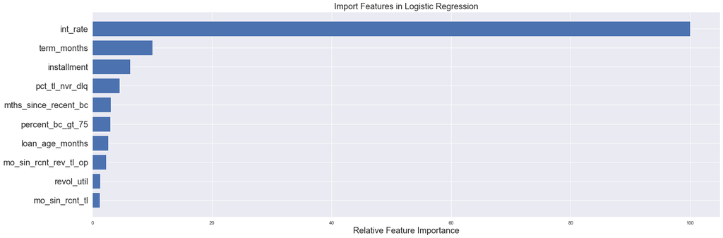

```python
feature_importance = abs(lr_clf.coef_[0])
feature_importance = 100.0 * (feature_importance / feature_importance.max())
sorted_idx = np.argsort(feature_importance)
sorted_idx = sorted_idx[-10:]
pos = np.arange(sorted_idx.shape[0]) + .5

featfig = plt.figure()
featax = featfig.add_subplot(1, 1, 1)
featax.barh(pos, feature_importance[sorted_idx], align='center')
featax.set_yticks(pos)
featax.set_yticklabels(np.array(X.columns)[sorted_idx], fontsize=20)
featax.set_xlabel('Relative Feature Importance', fontsize=20)
plt.title('Import Features in Logistic Regression', fontsize=20)
plt.tight_layout()
plt.show()
```

# KNN with PCA

We tried using K-Nearest Neighbors by experimenting different `K` values. Since the model has to compute distances in a multi-dimensional space, it is important that we reduce the number of dimension by transforming it using PCA.

```python
from sklearn.decomposition import PCA
pca_mod = PCA(n_components = .99)
pca_mod.fit(X_train_scaled)

X_train_projected = pca_mod.transform(X_train_scaled)
X_val_projected = pca_mod.transform(X_val_scaled)
X_test_projected = pca_mod.transform(X_test_scaled)
ncols = X_train_projected.shape[1]
print('With 99%% of the variance retained, we reduce the number of dimensions to %d' %(ncols))
```

```
With 99% of the variance retained, we reduce the number of dimensions to 11
```

```python
from sklearn.neighbors import KNeighborsClassifier

def KNN(k_values):
    for k in k_values:
        k_neighbor_clf = KNeighborsClassifier(k, n_jobs=5)
        k_neighbor_clf.fit(X_train_projected, y_train)

        predict_val = k_neighbor_clf.predict(X_val_projected)
        accuracy_val = metrics.accuracy_score(y_pred= predict_val,
                                                y_true = y_val)
        f1_val = metrics.f1_score(y_pred= predict_val, y_true = y_val)

        if k == 1:
            tuning = pd.DataFrame([[k,
                                    "%0.2f%%" % (accuracy_val * 100),
                                    "%0.2f%%" % (f1_val * 100)]],
                                  columns= ['K', 'Accuracy Val', 'F1 Val'])
        else:
            tuning = tuning.append(pd.DataFrame([[k,
                                                  "%0.2f%%" % (accuracy_val * 100),
                                                  "%0.2f%%" % (f1_val * 100)]],
                                  columns= ['K', 'Accuracy Val', 'F1 Val']),
                                  ignore_index=True)
    print(tuning)

k_values = [1, 3, 5, 7, 9, 10, 20, 50]
KNN(k_values)
```

```
    K Accuracy Val  F1 Val
0   1       92.35%  81.72%
1   3       93.81%  84.21%
2   5       94.00%  84.33%
3   7       93.89%  83.84%
4   9       93.76%  83.35%
5  10       93.23%  81.61%
6  20       92.75%  80.01%
7  50       91.81%  76.80%
```

Now we retrain with the best `K`:

```python
k_neighbor_clf = KNeighborsClassifier(5, n_jobs=5)
k_neighbor_clf.fit(X_train_projected, y_train)

predict_val = k_neighbor_clf.predict(X_val_projected)
accuracy_val = metrics.accuracy_score(y_pred= predict_val,
                                        y_true = y_val)
f1_val = metrics.f1_score(y_pred= predict_val, y_true = y_val)
print("The accuracy ratio of the validation sample is %.2f%%" %(accuracy_val * 100))
print("The f1 score of the validation sample is %.2f%%" %(f1_val * 100))
```

```
The accuracy ratio of the validation sample is 94.00%
The f1 score of the validation sample is 84.33%
```

# SVM

```python
from sklearn.svm import LinearSVC
svm_clf = LinearSVC()
svm_clf.fit(X_train_scaled, y_train)
```

```
LinearSVC(C=1.0, class_weight=None, dual=True, fit_intercept=True,
          intercept_scaling=1, loss='squared_hinge', max_iter=1000,
          multi_class='ovr', penalty='l2', random_state=None, tol=0.0001,
          verbose=0)
```

```python
predict_val = svm_clf.predict(X_val_scaled)
accuracy_val = metrics.accuracy_score(y_pred= predict_val,
                                        y_true = y_val)
f1_val = metrics.f1_score(y_pred= predict_val,
                            y_true = y_val)

print("The accuracy ratio of the validation sample is %.2f%%" %(accuracy_val * 100))
print("The f1 score of the validation sample is %.2f%%" %(f1_val * 100))
```

```
The accuracy ratio of the validation sample is 97.22%
The f1 score of the validation sample is 93.25%
```

# Random Forest

Try a random forest model, which is more scalable but needs tuning. Here we focus on the number of tress:

```python
RandomForestTuning()
```

```
   # trees Accuracy Val  F1 Val
0        5       98.14%  95.60%
1       10       98.32%  96.01%
2       20       98.51%  96.46%
3       50       98.64%  96.77%
4      100       98.66%  96.82%
```

Retrain the model with the best `n_estimators` of 100:

```python
rf_clf = RandomForestClassifier(n_estimators = 100, random_state = 0)
rf_clf.fit(X_train_scaled, y_train)
```

```
RandomForestClassifier(bootstrap=True, class_weight=None, criterion='gini',
                       max_depth=None, max_features='auto', max_leaf_nodes=None,
                       min_impurity_decrease=0.0, min_impurity_split=None,
                       min_samples_leaf=1, min_samples_split=2,
                       min_weight_fraction_leaf=0.0, n_estimators=100,
                       n_jobs=None, oob_score=False, random_state=0, verbose=0,
                       warm_start=False)
```

```python
feature_imp = pd.Series(rf_clf.feature_importances_,
                        index=X.columns).sort_values(ascending=False)

predict_val = rf_clf.predict(X_val_scaled)
accuracy_val = metrics.accuracy_score(y_pred= predict_val,
                                        y_true = y_val)
f1_val = metrics.f1_score(y_pred= predict_val,
                            y_true = y_val)

print("The accuracy ratio of the validation sample is %.2f%%" %(accuracy_val * 100))
print("The f1 score of the validation sample is %.2f%%" %(f1_val * 100))
```

```
The accuracy ratio of the validation sample is 98.66%
The f1 score of the validation sample is 96.82%
```

```
No handles with labels found to put in legend.
```

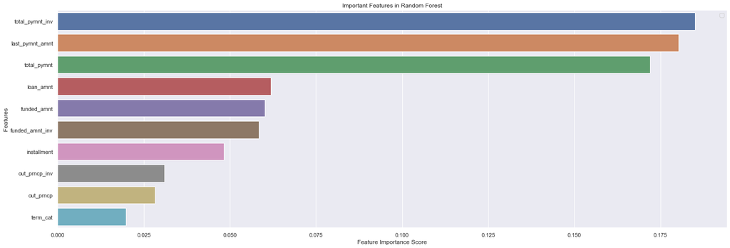

```python
sns.barplot(x=feature_imp[0:10], y=feature_imp.index[0:10])
# Add labels to your graph
plt.xlabel('Feature Importance Score')
plt.ylabel('Features')
plt.title("Important Features in Random Forest")
plt.legend()
plt.show()
```

# Naive Bayesian with PCA

```python
from sklearn.naive_bayes import GaussianNB, BernoulliNB

gnb_clf = GaussianNB(var_smoothing=.0001)
gnb_clf.fit(X_train_projected, y_train)
```

```
GaussianNB(priors=None, var_smoothing=0.0001)
```

```python
predict_val = gnb_clf.predict(X_val_projected)
accuracy_val = metrics.accuracy_score(y_pred= predict_val,
                                        y_true = y_val)
f1_val = metrics.f1_score(y_pred= predict_val,
                            y_true = y_val)
print("The accuracy ratio of the validation sample is %.2f%%" %(accuracy_val * 100))
print("The f1 score of the validation sample is %.2f%%" %(f1_val * 100))
```

```
The accuracy ratio of the validation sample is 92.46%
The f1 score of the validation sample is 79.45%
```

# Neural Network

```python
nnet_clr = keras.Sequential()
nnet_clr.add(keras.layers.Dense(16, input_dim=X_train_scaled.shape[1], activation='relu'))
nnet_clr.add(keras.layers.Dense(8, activation='relu'))
nnet_clr.add(keras.layers.Dense(1, activation='sigmoid'))
nnet_clr.compile(loss=f1_loss,
              optimizer='adam',
              metrics=['accuracy', f1])
hist = nnet_clr.fit(X_train_scaled, y_train, epochs=5, batch_size=10,
                   validation_data = (X_val_scaled, y_val))
```

```python
predict_val = nnet_clr.predict(X_val_scaled)
predict_val = (predict_val > .5)
accuracy_val = metrics.accuracy_score(y_pred = predict_val,
                                      y_true = y_val)
f1_val = metrics.f1_score(y_pred = predict_val, y_true = y_val)

print("The accuracy ratio of the validation sample is %.2f%%" %(accuracy_val * 100))
print("The f1 score of the validation sample is %.2f%%" %(f1_val * 100))
```

```
The accuracy ratio of the validation sample is 97.73%
The f1 score of the validation sample is 94.50%
```

# Model Comparison

```python
comparison = pd.DataFrame({'Models': ['LogisticRegression', 'KNN with PCA', 'SVM', 'Random Forest',
                                      'Naive Bayesian with PCA',
                                      'Neural Network'],
                           'F1 Score': [f1_test_lr, f1_test_knn, f1_test_svm, f1_test_rf, f1_test_nb, f1_test_nnet]})
print(comparison)
```

```
                    Models  F1 Score
0       LogisticRegression  0.947476
1             KNN with PCA  0.842852
2                      SVM  0.931911
3            Random Forest  0.968081
4  Naive Bayesian with PCA  0.793283
5           Neural Network  0.945154
```

The best model by `f1` score is Random Forest, even though some of the others came close. The important take-aways from this project are:

- we experimented with some of the most popular models and tested their suitability for dealing with unbalanced and high dimensional classifications;
- we have a model that shows consistent performance in training and testing;
- the model of our final recommendation, Random Forest, is one that is parsimonious and interpretable, and one we are comfortable to build on for further applications.